# Wrappers do `ggplot2` que já aplicam tema, paleta e formatação do guia automaticamente. Abaixo mostro como chamar cada um, com exemplos mínimos.

Hicham Tayfour — hichamt@al.insper.edu.br

São Paulo — 22/08/2025

Aqui eu começo o “coração” do meu kit de gráficos no padrão **The Economist**. A ideia foi concentrar todas as decisões visuais (cores, tipografia, grades e legendas) num **núcleo único e reutilizável**, para que depois eu só plugue os dados e o gráfico já saia no estilo certo.

Por que eu fiz assim?

- **Separação de estilo e conteúdo.** O estilo vive aqui; os gráficos só mapeiam dados → estética. Fica fácil manter, reutilizar e padronizar.
- **Fidelidade ao manual.** Cores e grades seguem o guia, inclusive o uso do cinza para “Outros”.
- **Ergonomia.** As funções prontas por tipo de gráfico deixam meus scripts curtos e práticos de adaptar.

A partir daqui, eu defino essas peças-base — e logo depois parto para os exemplos de cada tipo de gráfico.

# 1 🧰 Núcleo do Estilo (paletas, tema e helpers)

**Para que serve:** centralizar o estilo. Aqui ficam as paletas do guia, o tema base e as escalas auxiliares que padronizam cores, fontes e grades em todos os gráficos.

```r
# Pacotes
library(tidyverse)
library(scales)
library(showtext)

# Tipografia (fallback simples)
font_family <- if ("Roboto Condensed" %in% systemfonts::system_fonts()$family) "Roboto Condensed" else "sans"
showtext_auto()

# Paletas (as que usamos no projeto)
econ_colors <- list(
  main = c(
    econ_red   = "#E3120B",
    red1       = "#D86A77",
    red_text   = "#CC334C",
    blue1      = "#006BA2",
    blue2      = "#3EBCD2",
    blue2_text = "#0097A7"
  ),
  secondary = c(
    mustard   = "#E6B83C",
    burgundy  = "#A63D57",
    mauve     = "#B48A9B",
    teal      = "#008080",
    aqua      = "#6FC7C7"
  ),
  supporting_bright = c(
    purple = "#924C7A",
    pink   = "#DA3C78",
    orange = "#F7A11A",
    lime   = "#B3D334"
  ),
  supporting_dark = c(
    navy     = "#003D73",
    cyan_dk  = "#005F73",
    green_dk = "#385F44"
  ),
  background = c(
    print_bkgd = "#E9EDF0",
    highlight  = "#DDE8EF",
    number_box = "#C2D3E0"
  ),
  neutral = c(
    grid_lines = "#B7C6CF",
    grey_box   = "#7C8C99",
    grey_text  = "#333333",
    black25    = "#BFBFBF",
    black50    = "#808080",
    black75    = "#404040",
    black100   = "#000000"
  ),
  equal_lightness = c(
    red    = "#A81829",
    blue   = "#00588D",
    cyan   = "#005F73",
    green  = "#005F52",
    yellow = "#714C00",
    olive  = "#4C5900",
    purple = "#78405F",
    gold   = "#674E1F",
    grey   = "#3F5661"
  )
)

# Tokens base
econ_base <- list(
  bg   = econ_colors$background["print_bkgd"],
  grid = econ_colors$neutral["grid_lines"],
  text = "#0C0C0C"
)

# Ordens (conforme páginas do guia)
econ_order6 <- unname(c(
  econ_colors$main["blue1"], econ_colors$main["blue2"],
  econ_colors$secondary["mustard"], econ_colors$secondary["teal"],
  econ_colors$secondary["burgundy"], econ_colors$secondary["mauve"]
))
econ_stack6 <- unname(c(
  econ_colors$main["blue1"], econ_colors$main["blue2"],
  econ_colors$secondary["mustard"], econ_colors$main["blue2_text"],
  econ_colors$secondary["aqua"], econ_colors$equal_lightness["blue"]
))
econ_line_order6 <- unname(c(
  econ_colors$main["blue1"], econ_colors$main["blue2"],
  econ_colors$secondary["mustard"], econ_colors$secondary["burgundy"],
  econ_colors$main["blue2_text"], econ_colors$secondary["mauve"]
))
econ_line_stack_order6 <- econ_stack6
econ_thermo_order6 <- unname(c(
  econ_colors$main["blue2"], econ_colors$secondary["burgundy"],
  econ_colors$secondary["mustard"], econ_colors$main["blue1"],
  econ_colors$main["blue2_text"], econ_colors$secondary["mauve"]
))
econ_scatter_order6 <- unname(c(
  econ_colors$main["blue2"], econ_colors$secondary["burgundy"],
  econ_colors$secondary["mustard"], econ_colors$main["blue1"],
  econ_colors$main["blue2_text"], econ_colors$secondary["mauve"]
))
econ_pie_order6 <- unname(c(
  econ_colors$main["blue1"], econ_colors$main["blue2"],
  econ_colors$secondary["mustard"], econ_colors$main["blue2_text"],
  econ_colors$secondary["burgundy"], econ_colors$secondary["aqua"]
))

# Escalas auxiliares
scale_fill_econ <- function(palette = c("order6","equal_lightness","main","secondary",
                                        "supporting_bright","supporting_dark","neutral"),
                            values = NULL, reverse = FALSE, ...) {
  pal <- switch(match.arg(palette),
                order6 = econ_order6,
                equal_lightness = econ_colors$equal_lightness,
                main = econ_colors$main,
                secondary = econ_colors$secondary,
                supporting_bright = econ_colors$supporting_bright,
                supporting_dark   = econ_colors$supporting_dark,
                neutral = econ_colors$neutral)
  pal <- if (!is.null(values)) values else pal
  pal <- unname(pal)
  if (reverse) pal <- rev(pal)
  scale_fill_manual(values = pal, ...)
}
scale_colour_econ <- function(palette = c("order6","equal_lightness","main","secondary",
                                          "supporting_bright","supporting_dark","neutral"),
                              values = NULL, reverse = FALSE, ...) {
  pal <- switch(match.arg(palette),
                order6 = econ_order6,
                equal_lightness = econ_colors$equal_lightness,
                main = econ_colors$main,
                secondary = econ_colors$secondary,
                supporting_bright = econ_colors$supporting_bright,
                supporting_dark   = econ_colors$supporting_dark,
                neutral = econ_colors$neutral)
  pal <- if (!is.null(values)) values else pal
  pal <- unname(pal)
  if (reverse) pal <- rev(pal)
  scale_colour_manual(values = pal, ...)
}

# Tema base
theme_econ_base <- function(base_family = font_family) {
  theme_minimal(base_family = base_family) +
    theme(
      plot.background  = element_rect(fill = econ_base$bg, colour = NA),
      panel.background = element_rect(fill = econ_base$bg, colour = NA),
      plot.title.position = "plot",
      plot.title    = element_text(face = "bold", size = 20, hjust = 0, colour = econ_base$text, margin = margin(b = 2)),
      plot.subtitle = element_text(size = 12.5, hjust = 0, colour = econ_base$text, margin = margin(b = 8)),
      plot.caption  = element_text(size = 9, colour = econ_base$text),
      axis.title = element_text(size = 11, colour = econ_base$text),
      axis.text  = element_text(size = 10, colour = econ_base$text),
      axis.line.x  = element_line(colour = econ_base$text, linewidth = 0.6),
      axis.ticks.x = element_line(colour = econ_base$text, linewidth = 0.6),
      panel.grid.major.y = element_line(colour = econ_base$grid, linewidth = 0.4),
      panel.grid.major.x = element_blank(),
      panel.grid.minor   = element_blank(),
      legend.position = "top",
      legend.title = element_blank(),
      legend.text  = element_text(size = 10, colour = econ_base$text),
      plot.margin = margin(t = 16, r = 16, b = 12, l = 16)
    )
}
```

# 2 📊 Barras — Lado a Lado

**Quando usar:** para comparar valores entre diferentes categorias ou subgrupos, em um único ponto no tempo.

**Dica:** prefira barras horizontais quando os nomes das categorias forem longos — isso facilita a leitura dos rótulos.

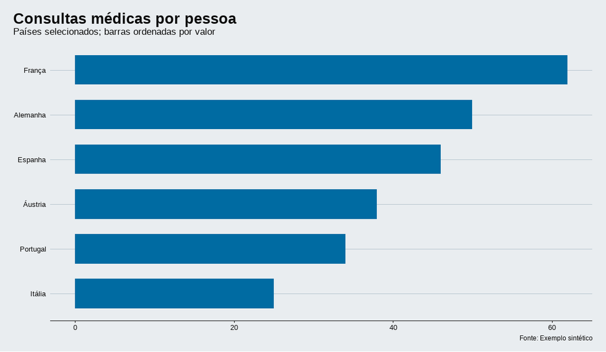

```r
# Função
econ_bar_side <- function(data,
                          x, y,
                          fill = NULL,
                          horizontal = TRUE,
                          palette = "order6",
                          legend = TRUE,
                          width = 0.66, dodge = 0.7,
                          labels = list(title=NULL, subtitle=NULL, x=NULL, y=NULL, caption=NULL),
                          format_values = c("number","percent","si")) {
  format_values <- match.arg(format_values)
  p <- ggplot(data, aes({{x}}, {{y}}))
  has_fill <- !rlang::quo_is_null(rlang::enquo(fill))
  if (has_fill) p <- p + aes(fill = {{fill}})
  if (has_fill) {
    p <- p + geom_col(width = width, position = position_dodge(width = dodge)) +
      scale_fill_econ(palette = palette)
  } else {
    p <- p + geom_col(width = width, fill = unname(econ_order6[1]))
  }
  if (format_values == "percent") p <- p + scale_y_continuous(labels = label_percent())
  if (format_values == "si")      p <- p + scale_y_continuous(labels = label_number_si())
  if (horizontal) p <- p + coord_flip()
  p <- p + theme_econ_base()
  if (!has_fill || !legend) p <- p + guides(fill = "none")
  p + labs(title=labels$title, subtitle=labels$subtitle, x=labels$x, y=labels$y, caption=labels$caption)
}

# Exemplo 1 — uma série (cada barra uma cor se quiser usar fill = pais)
set.seed(10)
df_bar1 <- tibble(
  pais = c("Alemanha","Áustria","Espanha","França","Itália","Portugal"),
  valor = round(runif(6, 20, 80), 0)
) %>% mutate(pais = forcats::fct_reorder(pais, valor))
econ_bar_side(
  df_bar1, x = pais, y = valor,
  labels = list(
    title = "Consultas médicas por pessoa",
    subtitle = "Países selecionados; barras ordenadas por valor",
    caption = "Fonte: Exemplo sintético"
  ),
  legend = FALSE
)
```

```r
# Exemplo 2 — duas séries
set.seed(11)
df_bar2 <- tibble(
  pais = rep(c("Chile","Brasil","México","Malásia","Polônia","Índia"), each = 2),
  grupo = rep(c("Classe média","Baixa renda"), times = 6),
  valor = runif(12, 0.10, 0.80)
)
econ_bar_side(
  df_bar2, x = pais, y = valor, fill = grupo,
  labels = list(
    title = "Defensores da democracia",
    subtitle = "Proporção dizendo que eleições são muito importantes",
    x = NULL, y = NULL, caption = "Fonte: Exemplo sintético"
  ),
  format_values = "percent"
)
```

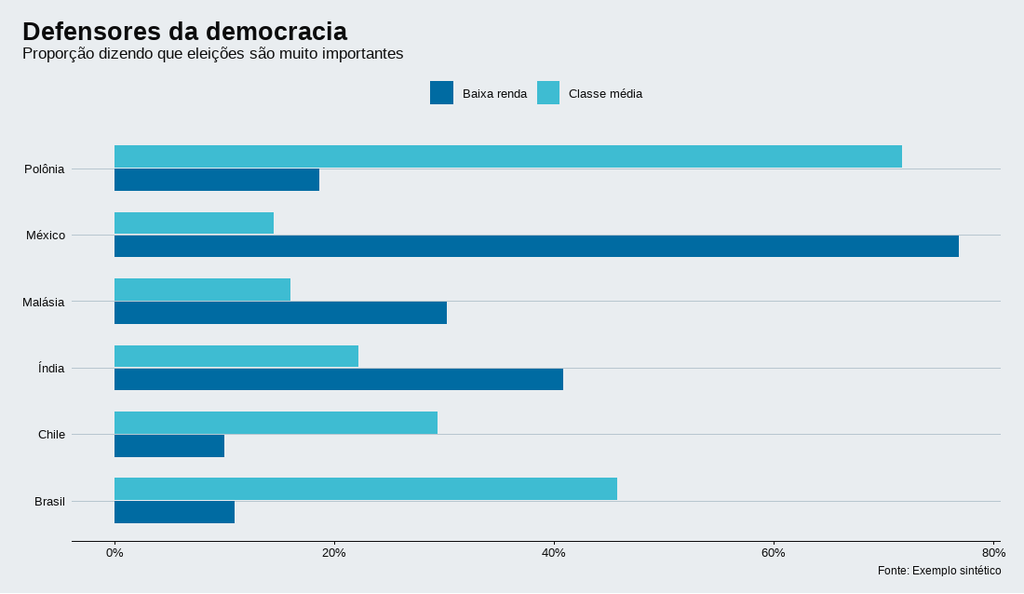

# 3 🧱 Barras — Empilhadas (absoluta e 100%)

**Quando usar:** para mostrar a composição de valores por categoria ou ao longo do tempo, destacando a contribuição de cada parte no total.

**Dica:** use a cor cinza para agrupar pequenas parcelas como “Outros”, mantendo o foco nas categorias principais.

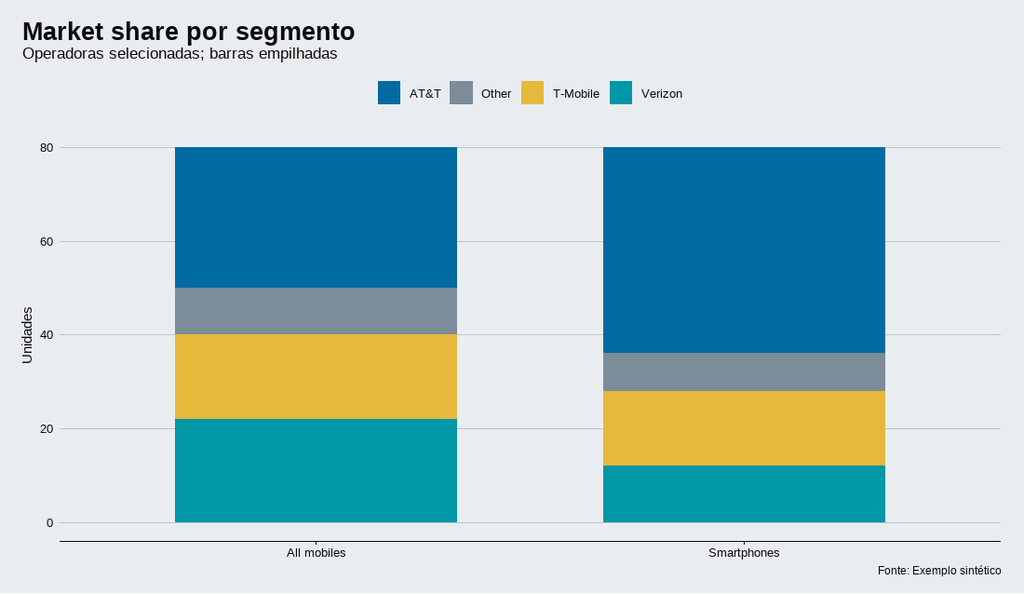

```r
econ_bar_stacked <- function(data, x, y, fill,
                             percent = FALSE, horizontal = FALSE, legend = TRUE,
                             other_levels = NULL, width = 0.66,
                             labels = list(title=NULL, subtitle=NULL, x=NULL, y=NULL, caption=NULL),
                             format_values = c("number","percent","si")) {
  format_values <- match.arg(format_values)
  p <- ggplot(data, aes({{x}}, {{y}}, fill = {{fill}})) +
    geom_col(width = width, position = if (percent) "fill" else "stack")
  lvls <- levels(factor(dplyr::pull(data, {{fill}})))
  pal_named <- setNames(rep_len(econ_stack6, length(lvls)), lvls)
  if (!is.null(other_levels))
    pal_named[names(pal_named) %in% other_levels] <- econ_colors$neutral["grey_box"]
  p <- p + scale_fill_manual(values = pal_named)
  if (percent || format_values == "percent") p <- p + scale_y_continuous(labels = label_percent())
  else if (format_values == "si")             p <- p + scale_y_continuous(labels = label_number_si())
  if (horizontal) p <- p + coord_flip()
  p <- p + theme_econ_base()
  if (!legend) p <- p + guides(fill = "none")
  if (horizontal) {
    p <- p + theme(panel.grid.major.y = element_blank(),
                   panel.grid.major.x = element_line(colour = econ_base$grid, linewidth = 0.4))
  }
  p + labs(title=labels$title, subtitle=labels$subtitle, x=labels$x, y=labels$y, caption=labels$caption)
}

# Exemplo — empilhada normal
set.seed(20)
df_stack1 <- tibble(
  segmento = rep(c("All mobiles","Smartphones"), each = 4),
  operador = rep(c("AT&T","T-Mobile","Verizon","Other"), times = 2),
  share    = c(30, 18, 22, 10, 44, 16, 12, 8)
)
econ_bar_stacked(
  df_stack1, x = segmento, y = share, fill = operador,
  other_levels = "Other",
  labels = list(
    title = "Market share por segmento",
    subtitle = "Operadoras selecionadas; barras empilhadas",
    x = NULL, y = "Unidades", caption = "Fonte: Exemplo sintético"
  )
)
```

```r
# Exemplo — 100% (horizontal)
set.seed(21)
df_stack2 <- tibble(
  ano   = rep(2018:2022, each = 5),
  canal = rep(c("Paid search","Display","Classified","Online video","Other"), times = 5),
  share = runif(25, 5, 35)
) %>%
  group_by(ano) %>%
  mutate(share = share/sum(share)) %>%
  ungroup()
econ_bar_stacked(
  df_stack2, x = ano, y = share, fill = canal,
  percent = TRUE, horizontal = TRUE, other_levels = "Other",
  labels = list(
    title = "Gasto em publicidade digital por canal",
    subtitle = "Barras empilhadas 100%",
    x = NULL, y = NULL, caption = "Fonte: Exemplo sintético"
  ),
  format_values = "percent"
)
```

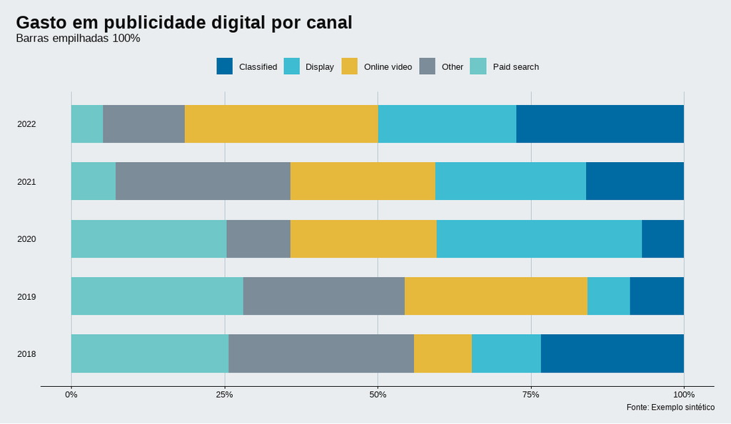

# 4 📈 Linhas — Lado a Lado

**Quando usar:** para comparar a evolução de 2 a 6 séries ao longo do tempo, permitindo identificar tendências e diferenças entre elas.

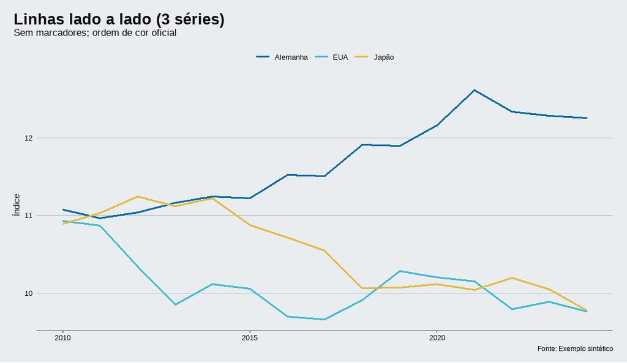

```r
econ_line_side <- function(data,
                           x, y, colour,
                           linewidth = 1.1, legend = TRUE,
                           labels = list(title=NULL, subtitle=NULL, x=NULL, y=NULL, caption=NULL),
                           format_y = c("number","percent","si")) {
  format_y <- match.arg(format_y)
  p <- ggplot(data, aes({{x}}, {{y}}, colour = {{colour}})) +
    geom_line(linewidth = linewidth, lineend = "round") +
    scale_colour_manual(values = econ_line_order6) +
    theme_econ_base()
  if (format_y == "percent") p <- p + scale_y_continuous(labels = label_percent())
  if (format_y == "si")      p <- p + scale_y_continuous(labels = label_number_si())
  if (!legend) p <- p + guides(colour = "none")
  p + labs(title=labels$title, subtitle=labels$subtitle, x=labels$x, y=labels$y, caption=labels$caption)
}

# Exemplo — 3 linhas
set.seed(42)
df_line3 <- tidyr::crossing(
  ano = 2010:2024, serie = c("Japão","EUA","Alemanha")
) %>%
  group_by(serie) %>%
  arrange(ano, .by_group = TRUE) %>%
  mutate(base = 10 + 0.8 * as.integer(factor(serie)),
         valor = base + cumsum(rnorm(n(), 0, 0.2))) %>%
  ungroup()
econ_line_side(
  df_line3, x = ano, y = valor, colour = serie,
  labels = list(
    title = "Linhas lado a lado (3 séries)",
    subtitle = "Sem marcadores; ordem de cor oficial",
    x = NULL, y = "Índice", caption = "Fonte: Exemplo sintético"
  )
)
```

```r
# Exemplo — 6 linhas
set.seed(99)
df_line6 <- tidyr::crossing(
  ano = 2010:2024, serie = paste0("S", 1:6)
) %>%
  group_by(serie) %>%
  arrange(ano, .by_group = TRUE) %>%
  mutate(base = 10 + 0.7 * as.integer(factor(serie)),
         valor = base + cumsum(rnorm(n(), 0, 0.3))) %>%
  ungroup()
econ_line_side(
  df_line6, x = ano, y = valor, colour = serie,
  labels = list(
    title = "Linhas lado a lado (6 séries)",
    subtitle = "Cores: azul, ciano, mostarda, bordô, teal, malva",
    x = NULL, y = "Índice", caption = "Fonte: Exemplo sintético"
  )
)
```

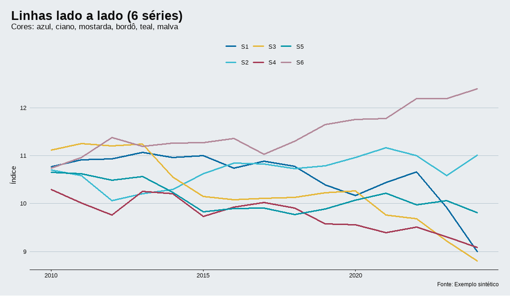

# 5 🧩 Linhas — Empilhadas (área / 100%)

**Quando usar:** para mostrar a soma de valores por grupo (área empilhada) ou a participação relativa de cada grupo ao longo do tempo (100%).

**Dica:** utilize a versão 100% quando o interesse for proporções; prefira a versão absoluta quando o foco for o volume total.

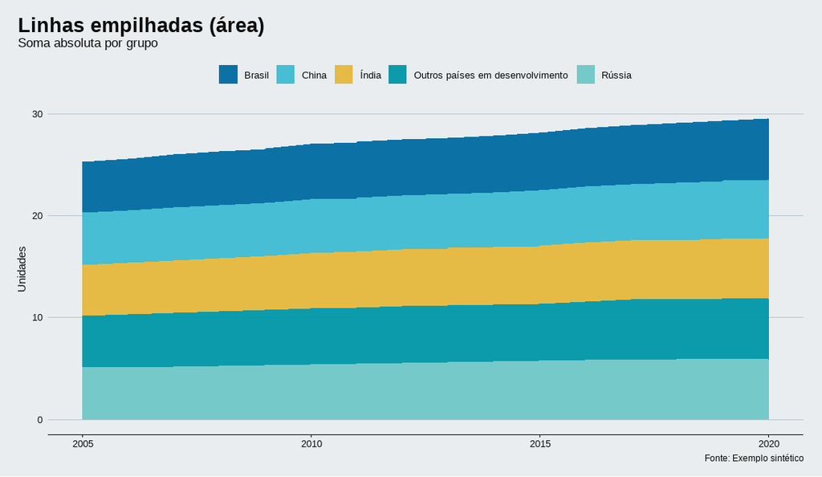

```r
econ_line_stacked <- function(data, x, y, fill,
                              percent = FALSE, legend  = TRUE, alpha = 0.95,
                              labels  = list(title=NULL, subtitle=NULL, x=NULL, y=NULL, caption=NULL),
                              format_y = c("number","percent","si"),
                              legend_reverse = FALSE) {
  format_y <- match.arg(format_y)
  p <- ggplot(data, aes({{x}}, {{y}}, fill = {{fill}})) +
    geom_area(position = if (percent) "fill" else "stack", alpha = alpha, colour = NA) +
    scale_fill_manual(values = econ_line_stack_order6) +
    theme_econ_base()
  if (percent || format_y == "percent") p <- p + scale_y_continuous(labels = label_percent())
  else if (format_y == "si")            p <- p + scale_y_continuous(labels = label_number_si())
  if (!legend) p <- p + guides(fill = "none")
  else if (legend_reverse) p <- p + guides(fill = guide_legend(reverse = TRUE))
  p + labs(title=labels$title, subtitle=labels$subtitle, x=labels$x, y=labels$y, caption=labels$caption)
}

# Exemplo — área empilhada
set.seed(123)
df_area_abs <- tidyr::crossing(
  ano   = 2005:2020,
  grupo = c("China","Outros países em desenvolvimento","Índia","Brasil","Rússia")
) %>%
  group_by(grupo) %>%
  arrange(ano, .by_group = TRUE) %>%
  mutate(base = c(5, 3.5, 2.8, 2.4, 2.0)[as.integer(factor(grupo))],
         fluxo = base + cumsum(abs(rnorm(n(), 0.05, 0.05)))) %>%
  ungroup()
econ_line_stacked(
  df_area_abs, x = ano, y = fluxo, fill = grupo,
  labels = list(
    title = "Linhas empilhadas (área)",
    subtitle = "Soma absoluta por grupo",
    x = NULL, y = "Unidades", caption = "Fonte: Exemplo sintético"
  )
)
```

```r
# Exemplo — 100%
set.seed(321)
df_area_pct <- tidyr::crossing(
  ano   = 2010:2022,
  grupo = c("Setor A","Setor B","Setor C","Setor D","Setor E","Setor F")
) %>%
  group_by(ano) %>%
  mutate(valor = rgamma(n(), 2, 1), share = valor / sum(valor)) %>%
  ungroup()
econ_line_stacked(
  df_area_pct, x = ano, y = share, fill = grupo,
  percent = TRUE,
  labels = list(
    title = "Linhas empilhadas 100%",
    subtitle = "Participação relativa por ano",
    x = NULL, y = NULL, caption = "Fonte: Exemplo sintético"
  ),
  format_y = "percent", legend_reverse = TRUE
)
```

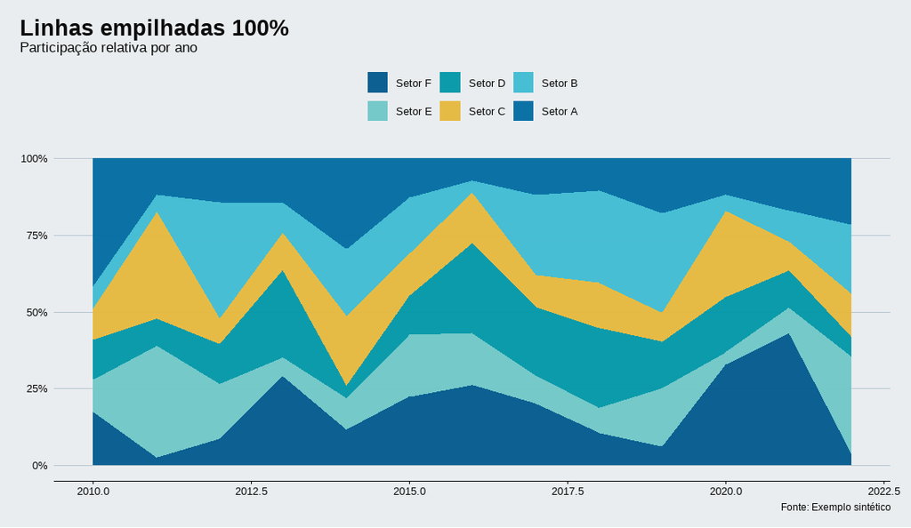

# 6 🌡️ Termômetro (haste + ponto / dot terminals)

**Quando usar:** para comparar valores pontuais entre categorias, permitindo visualizar diferenças de magnitude de forma clara.

**Dica:** use hastes cinza bem finas para dar contexto e pontos coloridos para destacar os valores; opte apenas pelos pontos (“dot terminals”) quando houver risco de poluição visual.

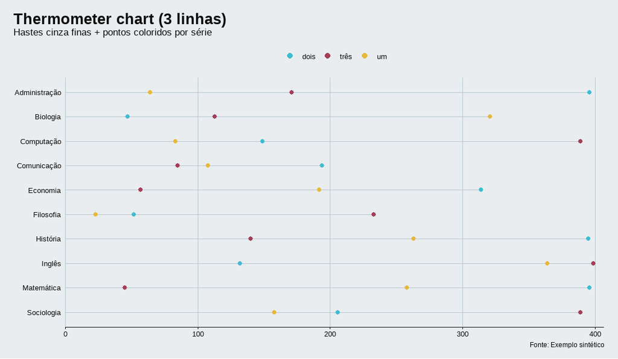

```r
econ_thermometer <- function(data, category, value, group = NULL,
                             segments = TRUE, stem_size = 0.6, dot_size  = 2.6,
                             legend = TRUE,
                             labels = list(title=NULL, subtitle=NULL, x=NULL, y=NULL, caption=NULL),
                             format_x = c("number","percent","si")) {
  format_x <- match.arg(format_x)
  df <- data %>%
    mutate(.cat = forcats::fct_rev(forcats::fct_inorder({{category}})),
           .grp = if (rlang::quo_is_null(rlang::enquo(group))) factor("value")
                  else forcats::fct_inorder({{group}}))
  p <- ggplot(df, aes(x = {{value}}, y = .cat, colour = .grp))
  if (segments) {
    p <- p + geom_segment(aes(x = 0, xend = {{value}}, y = .cat, yend = .cat),
                          inherit.aes = FALSE, colour = econ_colors$neutral["grid_lines"],
                          linewidth = stem_size, lineend = "round")
  }
  p <- p + geom_point(size = dot_size, stroke = 0)
  pal <- rep(econ_thermo_order6, length.out = nlevels(df$.grp)); names(pal) <- levels(df$.grp)
  p <- p + scale_colour_manual(values = pal)
  if (format_x == "percent") p <- p + scale_x_continuous(labels = label_percent(), expand = expansion(mult = c(0, .02)))
  if (format_x == "si")      p <- p + scale_x_continuous(labels = label_number_si(), expand = expansion(mult = c(0, .02)))
  if (format_x == "number")  p <- p + scale_x_continuous(expand = expansion(mult = c(0, .02)))
  p <- p + theme_econ_base() +
    theme(panel.grid.major.y = element_blank(),
          panel.grid.major.x = element_line(colour = econ_base$grid, linewidth = 0.4)) +
    expand_limits(x = 0)
  if (!legend || nlevels(df$.grp) == 1) p <- p + guides(colour = "none")
  else p <- p + guides(colour = guide_legend(override.aes = list(linetype = 0, size = 3)))
  p + labs(title=labels$title, subtitle=labels$subtitle, x=labels$x, y=labels$y, caption=labels$caption)
}

# Exemplo — 3 linhas
set.seed(7)
disc <- c("Matemática","Economia","Computação","Administração","Biologia",
          "Filosofia","História","Inglês","Comunicação","Sociologia")
df_th3 <- tidyr::crossing(disciplina = disc, grupo = c("um","dois","três")) %>%
  mutate(valor = round(runif(n(), 20, 400), 0))
econ_thermometer(
  df_th3, category = disciplina, value = valor, group = grupo,
  labels = list(
    title = "Thermometer chart (3 linhas)",
    subtitle = "Hastes cinza finas + pontos coloridos por série",
    x = NULL, y = NULL, caption = "Fonte: Exemplo sintético"
  ), format_x = "number"
)
```

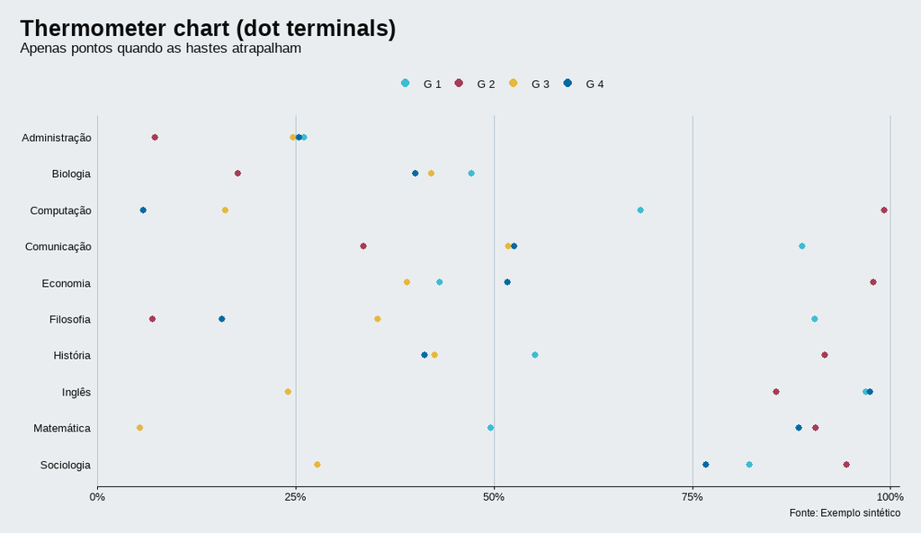

```r
# Exemplo — dot terminals em %
set.seed(9)
df_th4 <- tidyr::crossing(disciplina = disc, grupo = paste("G", 1:4)) %>%
  mutate(valor = runif(n(), 0.05, 1))
econ_thermometer(
  df_th4, category = disciplina, value = valor, group = grupo,
  segments = FALSE,
  labels = list(
    title = "Thermometer chart (dot terminals)",
    subtitle = "Apenas pontos quando as hastes atrapalham",
    x = NULL, y = NULL, caption = "Fonte: Exemplo sintético"
  ), format_x = "percent"
)
```